# Lab8

Jackson Hubbard

11/5/2018

# Question 1

```r
#load the data and glimpse into it
sp500 <- read_csv("sp500.csv")
glimpse(sp500)
```

```
## Observations: 509
## Variables: 2
## $ date   <date> 2003-01-03, 2003-01-10, 2003-01-17, 2003-01-24, 2003-0...
## $ return <dbl> 0.0372130249, 0.0206742938, -0.0281976508, -0.045811619...
```

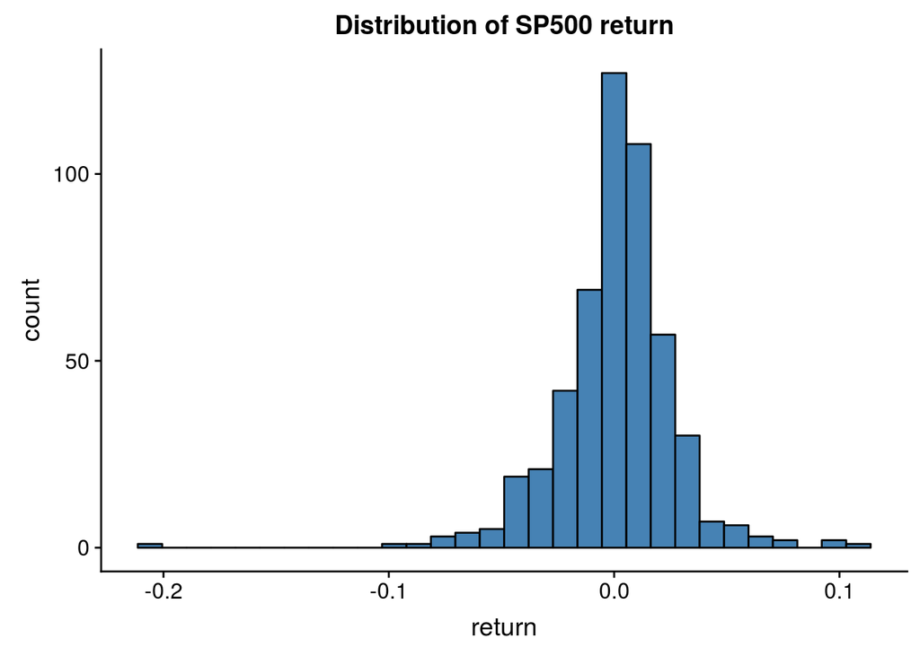

```r
# create ggplot of Dist. of return
ggplot(data=sp500,aes(x=return)) + geom_histogram(fill="steelblue",color="black") +
  labs(title="Distribution of SP500 return") +
  theme(plot.title=element_text(hjust=0.5))
```

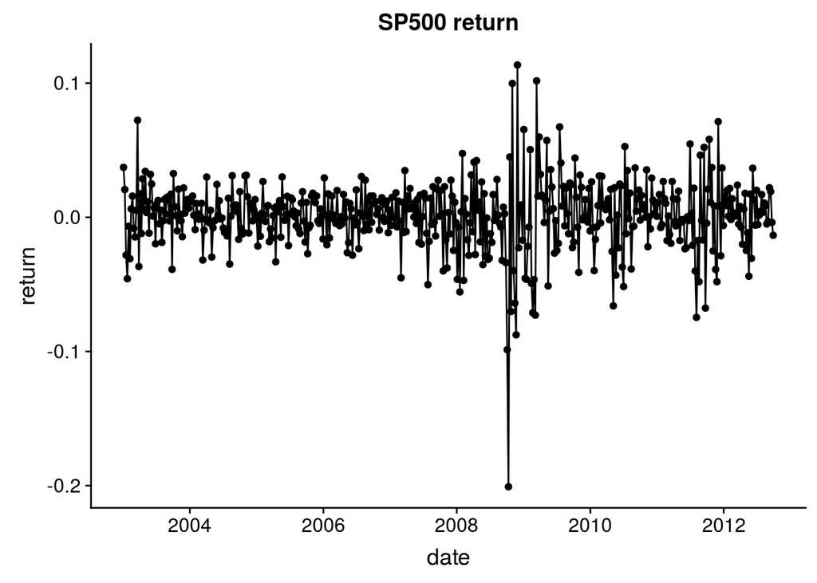

```r
# create ggplot of return over time
ggplot(data=sp500,aes(x=date,y=return)) + geom_point() + geom_line() +
  labs(title="SP500 return", sub.title="2003 - 2012") +
  theme(plot.title=element_text(hjust=0.5),plot.subtitle=element_text(hjust=0.5))
```

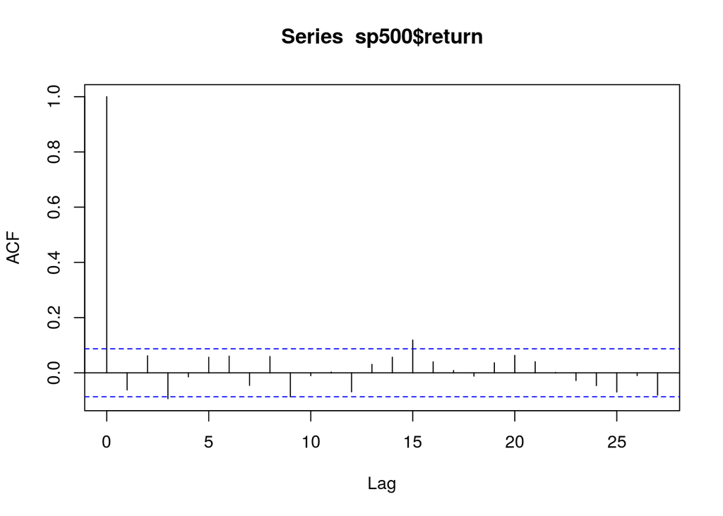

```r
# create ACF plot
p2 <- acf(sp500$return)
```

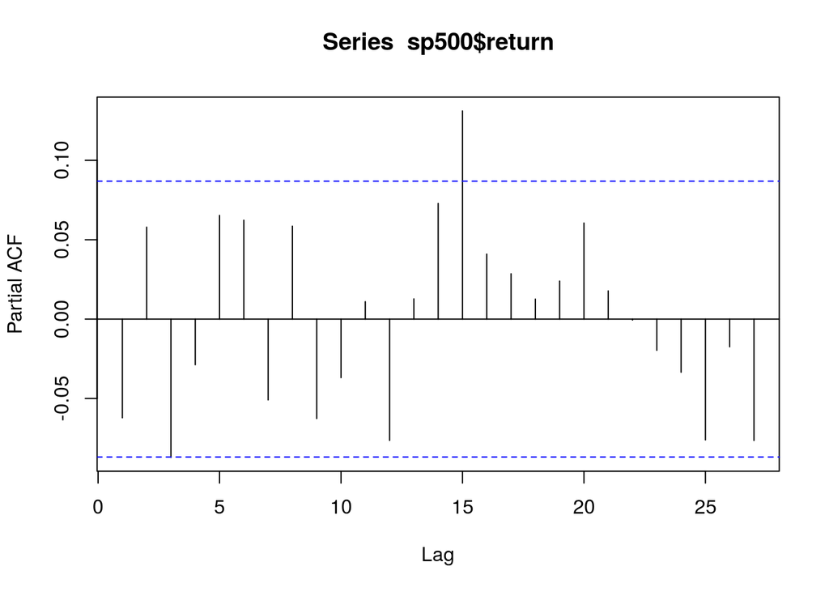

```r
# create PACF plot
p1 <- pacf(sp500$return)
```

```r
ar1_model <- arima(sp500$return,order=c(1,0,0))

kable(tidy(ar1_model),format="markdown",digits=3)
```

| term | estimate | std.error |
| --- | --- | --- |
| ar1 | -0.062 | 0.044 |
| intercept | 0.001 | 0.001 |

# Question 2

# a

# b

The time series is generally stationary (with relatively little fluctuations from the mean) with the exception of the financial crisis from 2008 to about 2012.

# Question 3

The ACF and PACF graph don’t seem to show a significant serial correlation as the only lag witha signifcance above the threshhold is 15. We can probably do more exploratory data analysis in order to determine why 15 is significant, but since only one lag value is above the threshold we can say that there is not significant serial correlation.

#Question 4

The confidence interva is -0.062 +/- 1.96*0.044 which equates to (-0.14824, 0.02424). Thus there is not significant autocorrelation between returns at time t and time t-1 as 0 is inlcuded in this interval.

# Question 1

```r
# load the data and filter for US from 2011 onward
us.data <- gapminder %>%
  filter(country=="United States", year <= 2011) %>%
  select(year,gdp,life_expectancy)
```

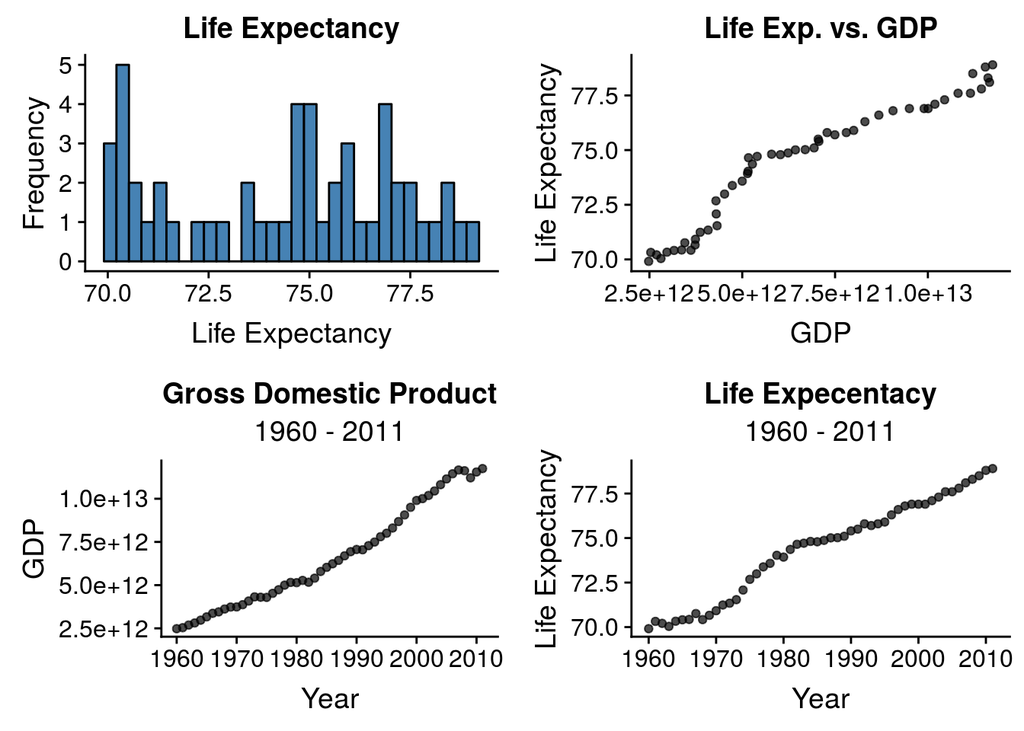

```r
# ggplots of explanatory and response variables
p1 <- ggplot(data=us.data,aes(x=life_expectancy)) +
  geom_histogram(fill="steelblue",color="black") +
  labs(title="Life Expectancy",
       x = "Life Expectancy", y="Frequency") +
  theme(plot.title=element_text(hjust=0.5))

p2 <- ggplot(data=us.data,aes(x=gdp, y=life_expectancy)) + geom_point(alpha=0.7) +
  labs(title="Life Exp. vs. GDP", x="GDP", y="Life Expectancy") +
  theme(plot.title=element_text(hjust=0.5))

p3 <- ggplot(data=us.data,aes(x=year, y=gdp)) + geom_point(alpha=0.7) +
  labs(title="Gross Domestic Product", subtitle="1960 - 2011",
       x="Year", y="GDP") +
  theme(plot.title=element_text(hjust=0.5), plot.subtitle=element_text(hjust=0.5))


p4 <- ggplot(data=us.data,aes(x=year, y=life_expectancy)) + geom_point(alpha=0.7) +
  labs(title="Life Expecentacy", subtitle="1960 - 2011",
       x="Year",y="Life Expectancy") +
  theme(plot.title=element_text(hjust=0.5), plot.subtitle=element_text(hjust=0.5))

plot_grid(p1,p2,p3,p4,ncol=2)
```

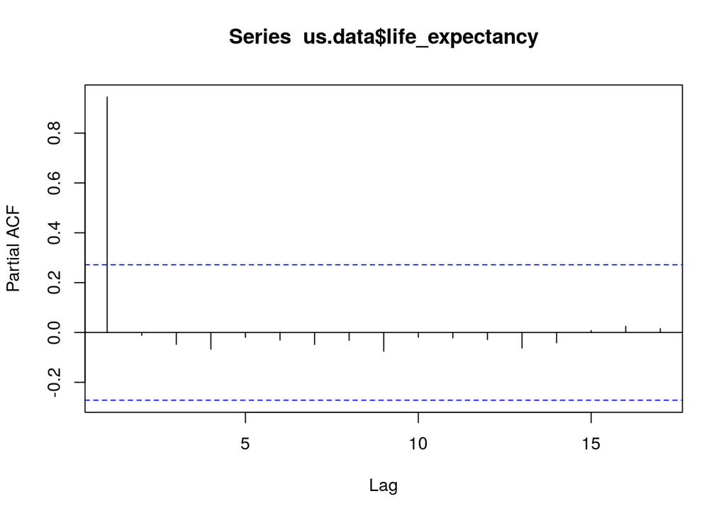

```r
# create pacf and acf plots for time series analysis
pacf(us.data$life_expectancy)
```

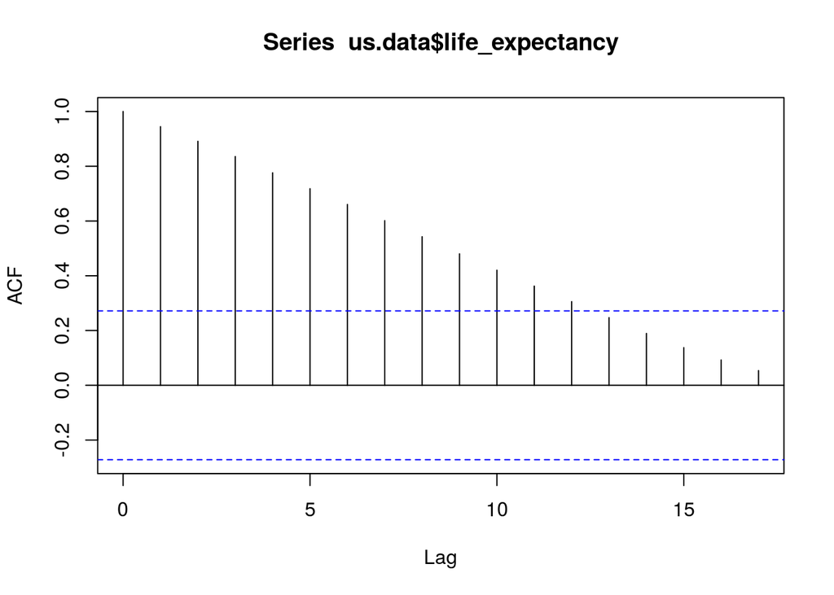

```r
acf(us.data$life_expectancy)
```

```r
# update the data with lags and remove last observation
us.data <- us.data %>% mutate(gdp.lag = lag(gdp,1),life.lag = lag(life_expectancy,1)) %>%
  slice(-1)

us.data <- us.data %>% mutate(gdp.diff = (gdp - gdp.lag)/gdp.lag,
                              life.diff = (life_expectancy - life.lag)/life.lag)
```

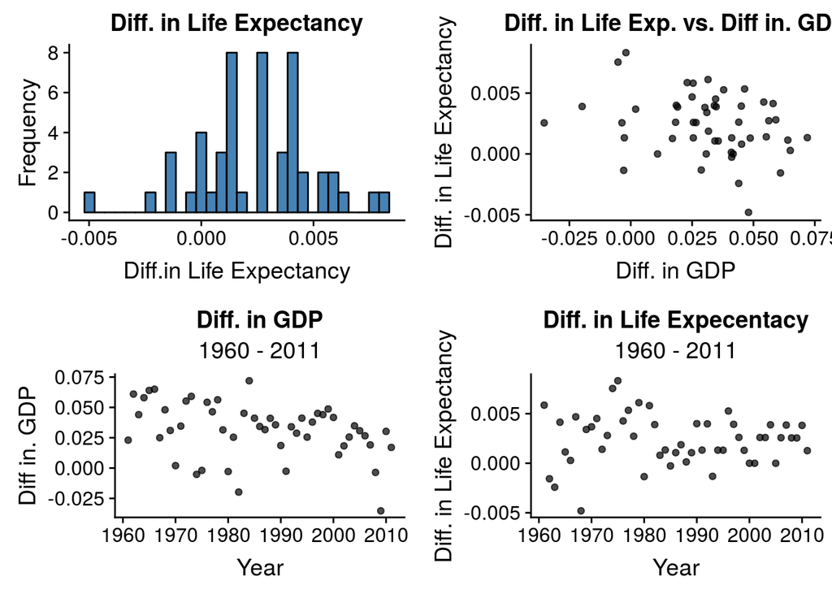

```r
# create ggplots of explanatory and response variables with lags
p1.diff <- ggplot(data=us.data,aes(x=life.diff)) +
  geom_histogram(fill="steelblue",color="black") +
  labs(title="Diff. in Life Expectancy",
       x = "Diff.in Life Expectancy", y="Frequency") +
  theme(plot.title=element_text(hjust=0.5))

p2.diff <- ggplot(data=us.data,aes(x=gdp.diff, y=life.diff)) + geom_point(alpha=0.7) +
  labs(title="Diff. in Life Exp. vs. Diff in. GDP", x="Diff. in GDP", y="Diff. in Life Expectancy") +
  theme(plot.title=element_text(hjust=0.5))

p3.diff <- ggplot(data=us.data,aes(x=year, y=gdp.diff)) + geom_point(alpha=0.7) +
  labs(title="Diff. in GDP", subtitle="1960 - 2011",
       x="Year", y="Diff in. GDP") +
  theme(plot.title=element_text(hjust=0.5), plot.subtitle=element_text(hjust=0.5))


p4.diff <- ggplot(data=us.data,aes(x=year, y=life.diff)) + geom_point(alpha=0.7) +
  labs(title="Diff. in Life Expecentacy", subtitle="1960 - 2011",
       x="Year",y="Diff. in Life Expectancy") +
  theme(plot.title=element_text(hjust=0.5), plot.subtitle=element_text(hjust=0.5))

plot_grid(p1.diff,p2.diff,p3.diff,p4.diff,ncol=2)
```

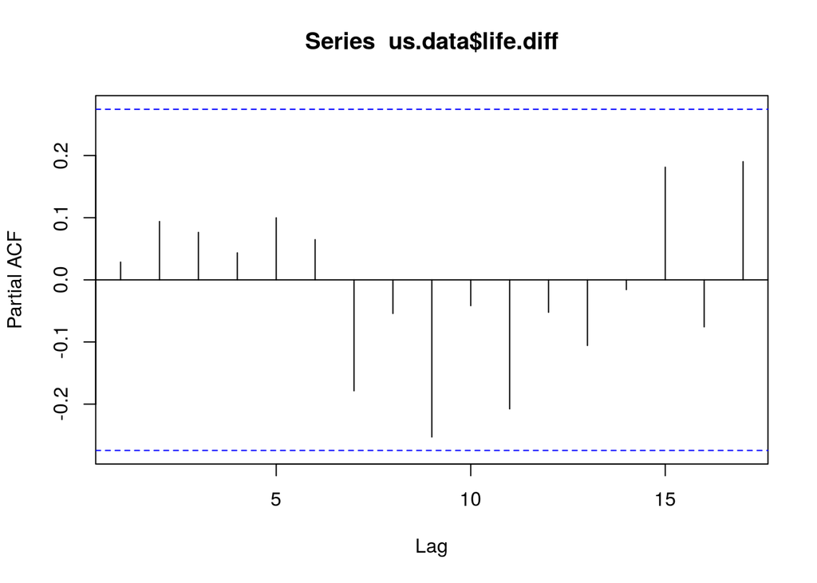

```r
# create pacf and acf plots with the lags
pacf(us.data$life.diff)
```

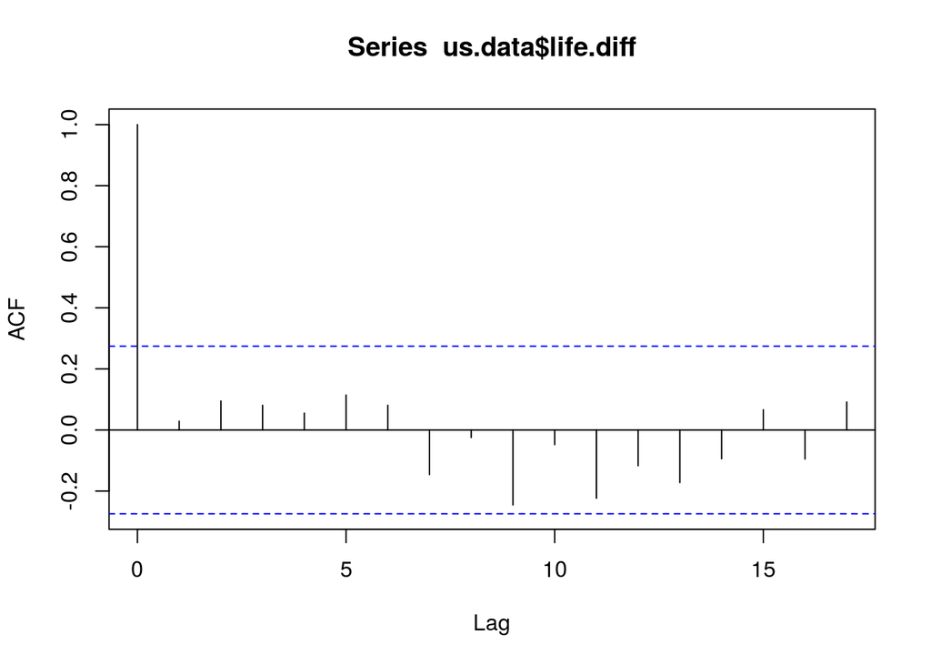

```r
acf(us.data$life.diff)
```

```r
# create first linear regression model using the lags
model1 <- lm(life.diff ~ gdp.diff, data=us.data)
kable(tidy(model1),format="markdown", digits=3)
```

| term | estimate | std.error | statistic | p.value |
| --- | --- | --- | --- | --- |
| (Intercept) | 0.003 | 0.001 | 5.630 | 0.000 |
| gdp.diff | -0.031 | 0.015 | -1.993 | 0.052 |

```r
kable(glance(model1),format="markdown",digits=3)
```

|  | r.squared | adj.r.squared | sigma | statistic | p.value | df | logLik | AIC | BIC | deviance | df.residual |
| --- | --- | --- | --- | --- | --- | --- | --- | --- | --- | --- | --- |
| value | 0.075 | 0.056 | 0.002 | 3.973 | 0.052 | 2 | 235.082 | -464.163 | -458.368 | 0 | 49 |

```r
# update the data with residuals
us.data <- us.data %>% mutate(Residuals = resid(model1), Predicted = predict.lm(model1))
```

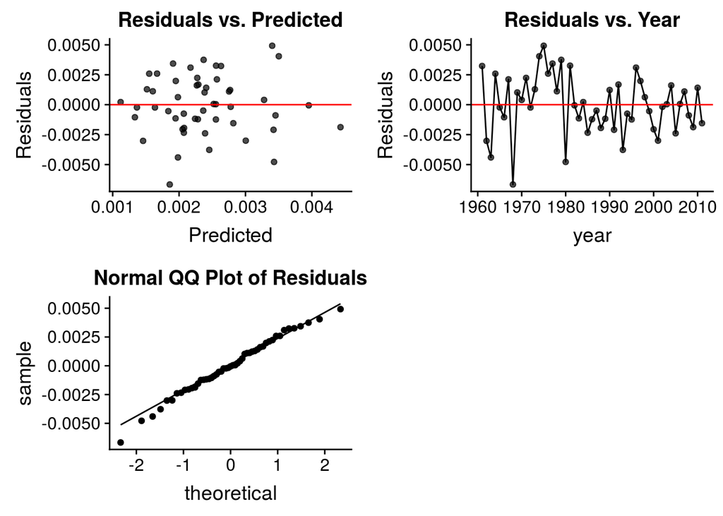

```r
# create ggplots of residuals
p5 <- ggplot(data=us.data, aes(x=Predicted, y=Residuals)) + geom_point(alpha=0.7) +
  geom_hline(yintercept=0,color="red") +
  labs(title="Residuals vs. Predicted") +
  theme(plot.title=element_text(hjust=0.5))

p6 <- ggplot(data=us.data, aes(x=year, y=Residuals)) + geom_point(alpha=0.7) + geom_line()+
  geom_hline(yintercept=0,color="red") +
  labs(title="Residuals vs. Year") +
  theme(plot.title=element_text(hjust=0.5))

p7 <- ggplot(data=us.data, aes(sample=Residuals)) + stat_qq() +
  stat_qq_line() +
  labs(title="Normal QQ Plot of Residuals") +
  theme(plot.title=element_text(hjust=0.5))

plot_grid(p5,p6,p7,ncol=2)
```

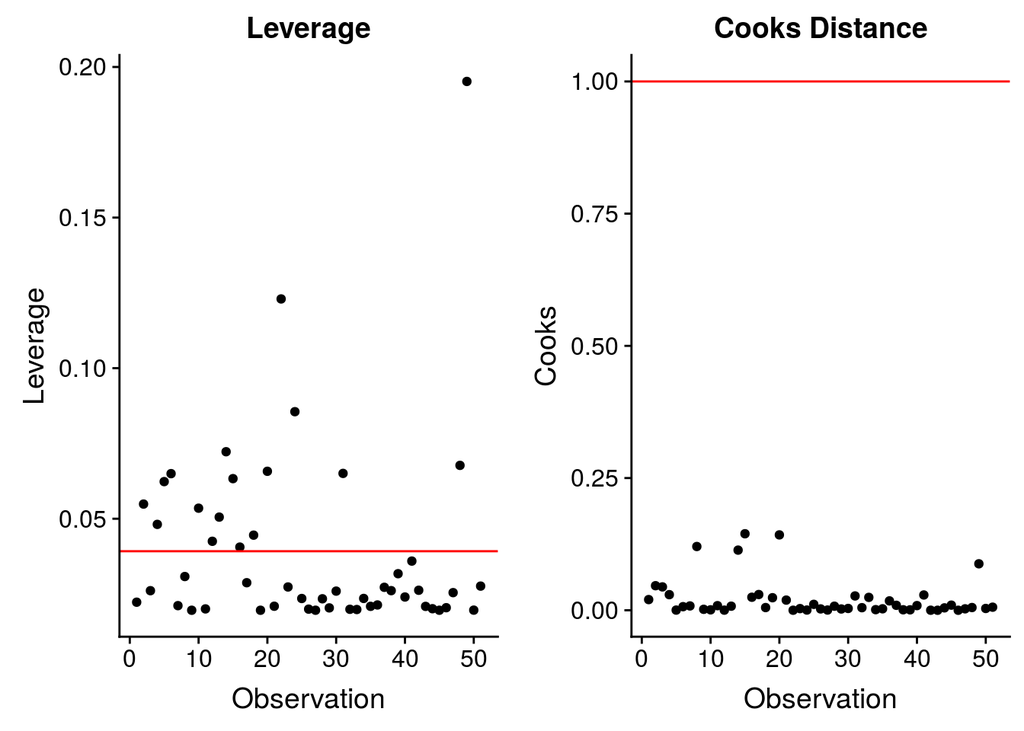

```r
# update data with leverage, cook's distance and obs # and use them to create ggplots for leverage and cooks distance
us.data <- us.data %>% mutate(Leverage = hatvalues(model1),
                              Cooks = cooks.distance(model1),
                              Observation = row_number())

leverage.threshold = 2*1/51

model1.lev <- ggplot(data=us.data,aes(x=Observation,y=Leverage)) + geom_point() +
  geom_hline(yintercept=leverage.threshold,color="red") +
  labs(title="Leverage")+
  theme(plot.title=element_text(hjust=0.5))

model1.cooks <- ggplot(data=us.data,aes(x=Observation,y=Cooks)) + geom_point() +
  geom_hline(yintercept=1,color="red") +
  labs(title="Cooks Distance")+
  theme(plot.title=element_text(hjust=0.5))

plot_grid(model1.lev, model1.cooks,ncol=2)
```

```r
# update the data with lag values
lag_data <- us.data %>% mutate(gdp.diff.lag1 = lag(gdp.diff,1)) %>%
  slice(-1)
```

```r
# create a second linear regression model
model2 <- lm(life.diff ~ gdp.diff.lag1,data=lag_data)
kable(tidy(model2),format="markdown", digits=3)
```

| term | estimate | std.error | statistic | p.value |
| --- | --- | --- | --- | --- |
| (Intercept) | 0.003 | 0.001 | 4.925 | 0.000 |
| gdp.diff.lag1 | -0.022 | 0.016 | -1.375 | 0.175 |

```r
kable(glance(model2),format="markdown",digits=3)
```

|  | r.squared | adj.r.squared | sigma | statistic | p.value | df | logLik | AIC | BIC | deviance | df.residual |
| --- | --- | --- | --- | --- | --- | --- | --- | --- | --- | --- | --- |
| value | 0.038 | 0.018 | 0.002 | 1.892 | 0.175 | 2 | 229.982 | -453.964 | -448.228 | 0 | 48 |

```r
# update data with residuals from second model
lag_data <- lag_data %>% mutate(Residuals = resid(model2), Predicted = predict.lm(model2))
```

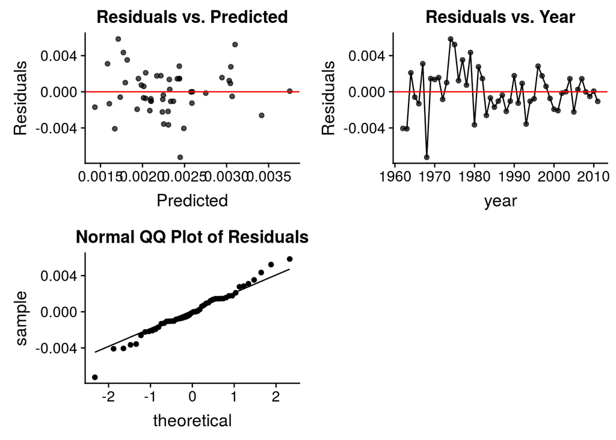

```r
# create ggplots of residuals
p8 <- ggplot(data=lag_data, aes(x=Predicted, y=Residuals)) + geom_point(alpha=0.7) +
  geom_hline(yintercept=0,color="red") +
  labs(title="Residuals vs. Predicted") +
  theme(plot.title=element_text(hjust=0.5))

p9 <- ggplot(data=lag_data, aes(x=year, y=Residuals)) + geom_point(alpha=0.7) + geom_line()+
  geom_hline(yintercept=0,color="red") +
  labs(title="Residuals vs. Year") +
  theme(plot.title=element_text(hjust=0.5))

p10 <- ggplot(data=lag_data, aes(sample=Residuals)) + stat_qq() +
  stat_qq_line() +
  labs(title="Normal QQ Plot of Residuals") +
  theme(plot.title=element_text(hjust=0.5))

plot_grid(p8,p9,p10,ncol=2)
```

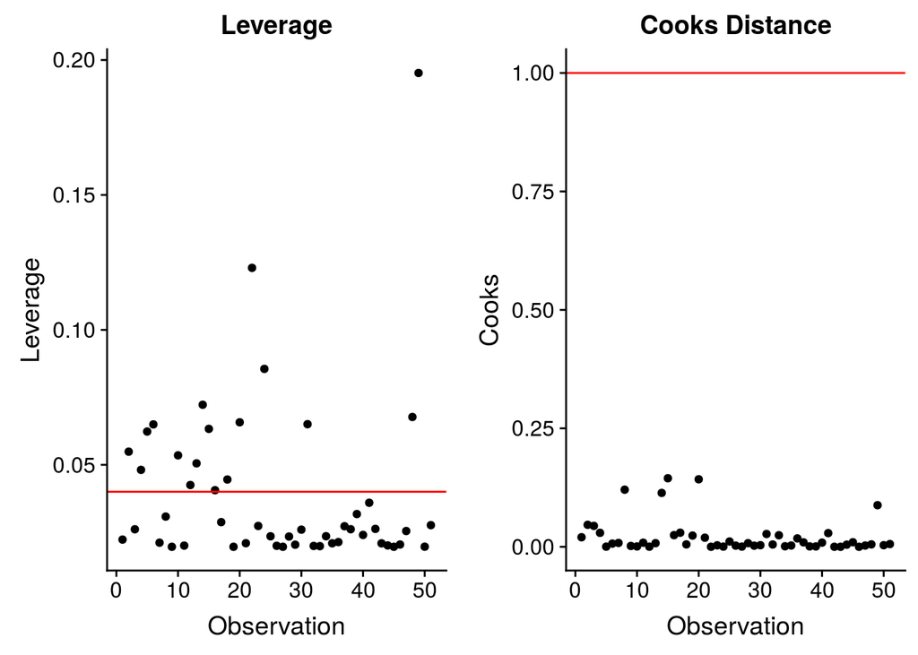

```r
# update data with leverage, cook's distance and obs # and use them to create ggplots for leverage and cooks distance

lag_data <- lag_data %>% mutate(Leverage = hatvalues(model2),
                              Cooks = cooks.distance(model2),
                              Observation = row_number())
leverage.threshold = 2*1/50

model2.lev <- ggplot(data=us.data,aes(x=Observation,y=Leverage)) + geom_point() +
  geom_hline(yintercept=leverage.threshold,color="red") +
  labs(title="Leverage")+
  theme(plot.title=element_text(hjust=0.5))

model2.cooks <- ggplot(data=us.data,aes(x=Observation,y=Cooks)) + geom_point() +
  geom_hline(yintercept=1,color="red") +
  labs(title="Cooks Distance")+
  theme(plot.title=element_text(hjust=0.5))

plot_grid(model2.lev, model2.cooks,ncol=2)
```

# Question 2

Looking at the exploratory data analysis we see that life_expectancy trends upward as time goes on so it seems that it is a not a stationary time series.

# Question 3

Based on the ACF and PCF plots for life.diff, it seems that there is no evidence of a significant serial correlation as none of the lines are above the threshold for PACF or ACF.

# Question 4.

# a

For every increase in a country’s GDP, the country’s life expectancy will is expected to change by -0.031 years from the prevoius year’s life expectancy.

# b

gdp.diff has a p value of 0.052, which is slightly over the significance threshold of 0.05. This means that it is not significant but it is safe to say that it has a moderatly significant effect on life.diff.

# c

7.5% of the variation in life.diff is explained by gdp.diff.

# Question 5

# a

For every increase in a country’s GDP in the time period from two years ago to one year ago, a country’s life expectancy in the current year is expected to change by -0.022 years from the previous year.

# b

The p value for gdp.diff.lag1 is 0.175, which is very high. This means that a country’s GDP change from two years ago to one year ago does not have a significant effect on a country’s life expectancy change from the previous year.

# c

3.8% of the variation in life.diff is explained by gdp.diff.lag1.

# Question 6

Yes these low R-squared values make sense in the context of the data, as it is clear that it is not a stationary time series. Therefore, we need a better model if we want to be more effective in predicting life expectancy from gdp.